# Project Code

teamname.isna()

Author

Abenezer, Arush, Melissa, Abby

Published

February 27, 2023

Abstract

## 1 Data quality check / cleaning / preparation - Abby Burt

### 1.1 Data quality check - Abby Burt

The code below visualizes the distribution of the variables in the dataset and how they interact with each other.

```python
import pandas as pd
import numpy as np
import statsmodels.formula.api as smf
import statsmodels.api as sm
import seaborn as sns
import matplotlib.pyplot as plt
import scipy.stats as st
import sklearn
import warnings
import itertools
import time
warnings.filterwarnings('ignore')

data = pd.read_csv('Algerian_forest_fires_dataset_UPDATE.csv',header=1)

df = data.copy()
df.head()
```

|  | day | month | year | Temperature | RH | Ws | Rain | FFMC | DMC | DC | ISI | BUI | FWI | Classes |
| --- | --- | --- | --- | --- | --- | --- | --- | --- | --- | --- | --- | --- | --- | --- |
| 0 | 01 | 06 | 2012 | 29 | 57 | 18 | 0 | 65.7 | 3.4 | 7.6 | 1.3 | 3.4 | 0.5 | not fire |
| 1 | 02 | 06 | 2012 | 29 | 61 | 13 | 1.3 | 64.4 | 4.1 | 7.6 | 1 | 3.9 | 0.4 | not fire |
| 2 | 03 | 06 | 2012 | 26 | 82 | 22 | 13.1 | 47.1 | 2.5 | 7.1 | 0.3 | 2.7 | 0.1 | not fire |
| 3 | 04 | 06 | 2012 | 25 | 89 | 13 | 2.5 | 28.6 | 1.3 | 6.9 | 0 | 1.7 | 0 | not fire |
| 4 | 05 | 06 | 2012 | 27 | 77 | 16 | 0 | 64.8 | 3 | 14.2 | 1.2 | 3.9 | 0.5 | not fire |

```python
#...Distribution of continuous variables...#
summary = df.describe(include='all')

missing_values = df.isnull().sum()
cat_dist = pd.DataFrame(columns=['unique_values', 'top_values'])

summary.loc['missing_values'] = missing_values

for column in df.columns:
    if df[column].dtype == np.object:
        unique_values = df[column].nunique()
        frequency = df[column].value_counts(normalize=True)
        cat_dist.loc[column] = [unique_values, frequency]

summary
```

|  | day | month | year | Temperature | RH | Ws | Rain | FFMC | DMC | DC | ISI | BUI | FWI | Classes |
| --- | --- | --- | --- | --- | --- | --- | --- | --- | --- | --- | --- | --- | --- | --- |
| count | 246 | 245 | 245 | 245 | 245 | 245 | 245 | 245 | 245 | 245 | 245 | 245 | 245 | 244 |
| unique | 33 | 5 | 2 | 20 | 63 | 19 | 40 | 174 | 167 | 199 | 107 | 175 | 128 | 9 |
| top | 01 | 07 | 2012 | 35 | 64 | 14 | 0 | 88.9 | 7.9 | 8 | 1.1 | 3 | 0.4 | fire |
| freq | 8 | 62 | 244 | 29 | 10 | 43 | 133 | 8 | 5 | 5 | 8 | 5 | 12 | 131 |
| missing_values | 0 | 1 | 1 | 1 | 1 | 1 | 1 | 1 | 1 | 1 | 1 | 1 | 1 | 2 |

```python
cat_dist
```

|  | unique_values | top_values |
| --- | --- | --- |
| day | 33 | 01 0.032520 02 ... |
| month | 5 | 07 0.253061 08 0.253061 06 0... |
| year | 2 | 2012 0.995918 year 0.004082 Name: year, ... |
| Temperature | 20 | 35 0.118367 31 0.10204... |
| RH | 63 | 64 0.040816 55 0.040816 58 0.03265... |
| Ws | 19 | 14 0.175510 15 0.163265 13 0.12244... |
| Rain | 40 | 0 0.542857 0.1 0.073469 0.2 0... |
| FFMC | 174 | 88.9 0.032653 89.4 0.020408 89.1 0.01... |
| DMC | 167 | 7.9 0.020408 12.5 0.016327 1.9 0.01... |
| DC | 199 | 8 0.020408 7.6 0.016327 7.8 0... |
| ISI | 107 | 1.1 0.032653 1.2 0.028571 0.4 0.02... |
| BUI | 175 | 3 0.020408 5.1 0.016327 8.3 0.01... |
| FWI | 128 | 0.4 0.048980 0.8 0.040816 0 0.03... |
| Classes | 9 | fire 0.536885 not fire 0.4... |

```python
## Demonstrates relationships between all variables
```

```python
sns.pairplot(df)
plt.show()
```

[output not shown]

### 1.2 Data Cleaning and Preparation

*By Abby*

From the data quality check we realized that:

1. Many columns were not a numeric type. So, we converted the datatype of these columns to numeric.
2. The dataset was incorrectly labelled by extra rows that were unnecessary with missing values. They did not hold any fire data but were used as labels. The first 122 rows the data set were of Bejaia, and the rows 123 onwards was for Sidi-Bel Abbes. To correct this labelling issue, we assigned each region by a number, 1 or 2.
3. Our data is mostly very clean.
4. There were a lot of unecessary spacing in the values, so we needed to strip them.
5. Only two missing values, one for the aforementioned row, and one for an instance. We dropped it.
6. We need assigned numbers for whether a fire occurred or not, 0 for no fire and 1 for fire.
7. From the summary provided in the code below, we see that there is no data that seems out of the ordinary to raise concern.

The code below implements the above cleaning.

```python
#dropping missing vals
df.dropna(inplace=True)

# dropping a row that was just for labelling
df = df.drop(index=123,axis=0)
```

```python
# Region 1 and 2
# Region 1 is Bejaia and Region 2 is Sidi Bel-Abbes
df.loc[:122,'Region']=1
df.loc[122:,'Region']=2
df[['Region']] = df[['Region']].astype(int)
df.columns
```

```
Index(['day', 'month', 'year', 'Temperature', ' RH', ' Ws', 'Rain ', 'FFMC',
       'DMC', 'DC', 'ISI', 'BUI', 'FWI', 'Classes  ', 'Region'],
      dtype='object')
```

```python
# getting rid of column names weird spacing
df.columns=df.columns.str.strip()
df.columns
```

```
Index(['day', 'month', 'year', 'Temperature', 'RH', 'Ws', 'Rain', 'FFMC',
       'DMC', 'DC', 'ISI', 'BUI', 'FWI', 'Classes', 'Region'],
      dtype='object')
```

```python
#Converting Not fire/Fire (with unnecessary spacing) to 0 and 1
print(df['Classes'].unique())
```

```
['not fire   ' 'fire   ' 'fire' 'fire ' 'not fire' 'not fire '
 'not fire     ' 'not fire    ']
```

```python
df.Classes=df.Classes.str.strip()
df.Classes.unique()
```

```
array(['not fire', 'fire'], dtype=object)
```

```python
df.dtypes
```

```
day            object
month          object
year           object
Temperature    object
RH             object
Ws             object
Rain           object
FFMC           object
DMC            object
DC             object
ISI            object
BUI            object
FWI            object
Classes        object
Region          int64
dtype: object
```

```python
# No null values
df.isnull().sum()
```

```
day            0
month          0
year           0
Temperature    0
RH             0
Ws             0
Rain           0
FFMC           0
DMC            0
DC             0
ISI            0
BUI            0
FWI            0
Classes        0
Region         0
dtype: int64
```

```python
# No duplicates
df.duplicated().sum()
```

```
0
```

```python
df['Classes'] = df['Classes'].replace('not fire', 0)
df['Classes'] = df['Classes'].replace('fire', 1)
df.Classes.unique()
```

```
array([0, 1])
```

```python
# converting column data types
df['DC']=df['DC'].astype('float')
df['ISI']=df['ISI'].astype('float')
df['BUI']=df['BUI'].astype('float')
df['FWI']=df['FWI'].astype('float')
df['day']=df['day'].astype('int')
df['month']=df['month'].astype('int')
df['year']=df['year'].astype('int')
df['Temperature']=df['Temperature'].astype('int')
df['RH']=df['RH'].astype('int')
df['Ws']=df['Ws'].astype('int')
df['Rain']=df['Rain'].astype('float')
df['FFMC']=df['FFMC'].astype('float')
df['DMC']=df['DMC'].astype('float')
df
```

|  | day | month | year | Temperature | RH | Ws | Rain | FFMC | DMC | DC | ISI | BUI | FWI | Classes | Region |
| --- | --- | --- | --- | --- | --- | --- | --- | --- | --- | --- | --- | --- | --- | --- | --- |
| 0 | 1 | 6 | 2012 | 29 | 57 | 18 | 0.0 | 65.7 | 3.4 | 7.6 | 1.3 | 3.4 | 0.5 | 0 | 1 |
| 1 | 2 | 6 | 2012 | 29 | 61 | 13 | 1.3 | 64.4 | 4.1 | 7.6 | 1.0 | 3.9 | 0.4 | 0 | 1 |
| 2 | 3 | 6 | 2012 | 26 | 82 | 22 | 13.1 | 47.1 | 2.5 | 7.1 | 0.3 | 2.7 | 0.1 | 0 | 1 |
| 3 | 4 | 6 | 2012 | 25 | 89 | 13 | 2.5 | 28.6 | 1.3 | 6.9 | 0.0 | 1.7 | 0.0 | 0 | 1 |
| 4 | 5 | 6 | 2012 | 27 | 77 | 16 | 0.0 | 64.8 | 3.0 | 14.2 | 1.2 | 3.9 | 0.5 | 0 | 1 |
| ... | ... | ... | ... | ... | ... | ... | ... | ... | ... | ... | ... | ... | ... | ... | ... |
| 241 | 26 | 9 | 2012 | 30 | 65 | 14 | 0.0 | 85.4 | 16.0 | 44.5 | 4.5 | 16.9 | 6.5 | 1 | 2 |
| 242 | 27 | 9 | 2012 | 28 | 87 | 15 | 4.4 | 41.1 | 6.5 | 8.0 | 0.1 | 6.2 | 0.0 | 0 | 2 |
| 243 | 28 | 9 | 2012 | 27 | 87 | 29 | 0.5 | 45.9 | 3.5 | 7.9 | 0.4 | 3.4 | 0.2 | 0 | 2 |
| 244 | 29 | 9 | 2012 | 24 | 54 | 18 | 0.1 | 79.7 | 4.3 | 15.2 | 1.7 | 5.1 | 0.7 | 0 | 2 |
| 245 | 30 | 9 | 2012 | 24 | 64 | 15 | 0.2 | 67.3 | 3.8 | 16.5 | 1.2 | 4.8 | 0.5 | 0 | 2 |

243 rows × 15 columns

```python
# Shuffling the dataset
df_shuffled = df.sample(frac=1, random_state=42)
df = df_shuffled.reset_index(drop=True)
```

```python
summary = df.describe(include='all')

missing_values = df.isnull().sum()

summary.loc['missing_values'] = missing_values

cat_dist = pd.DataFrame(columns=['unique_values', 'frequency'])

for column in df.columns:
    if df[column].dtype == np.object:
        unique_values = df[column].nunique()
        frequency = df[column].value_counts(normalize=True)
        cat_dist.loc[column] = [unique_values, frequency]

summary

#Here is the same summary shown before, except now everything is properly cleaned
```

|  | day | month | year | Temperature | RH | Ws | Rain | FFMC | DMC | DC | ISI | BUI | FWI | Classes | Region |
| --- | --- | --- | --- | --- | --- | --- | --- | --- | --- | --- | --- | --- | --- | --- | --- |
| count | 243.000000 | 243.000000 | 243.0 | 243.000000 | 243.000000 | 243.000000 | 243.000000 | 243.000000 | 243.000000 | 243.000000 | 243.000000 | 243.000000 | 243.000000 | 243.000000 | 243.000000 |
| mean | 15.761317 | 7.502058 | 2012.0 | 32.152263 | 62.041152 | 15.493827 | 0.762963 | 77.842387 | 14.680658 | 49.430864 | 4.742387 | 16.690535 | 7.035391 | 0.563786 | 1.497942 |
| std | 8.842552 | 1.114793 | 0.0 | 3.628039 | 14.828160 | 2.811385 | 2.003207 | 14.349641 | 12.393040 | 47.665606 | 4.154234 | 14.228421 | 7.440568 | 0.496938 | 0.501028 |
| min | 1.000000 | 6.000000 | 2012.0 | 22.000000 | 21.000000 | 6.000000 | 0.000000 | 28.600000 | 0.700000 | 6.900000 | 0.000000 | 1.100000 | 0.000000 | 0.000000 | 1.000000 |
| 25% | 8.000000 | 7.000000 | 2012.0 | 30.000000 | 52.500000 | 14.000000 | 0.000000 | 71.850000 | 5.800000 | 12.350000 | 1.400000 | 6.000000 | 0.700000 | 0.000000 | 1.000000 |
| 50% | 16.000000 | 8.000000 | 2012.0 | 32.000000 | 63.000000 | 15.000000 | 0.000000 | 83.300000 | 11.300000 | 33.100000 | 3.500000 | 12.400000 | 4.200000 | 1.000000 | 1.000000 |
| 75% | 23.000000 | 8.000000 | 2012.0 | 35.000000 | 73.500000 | 17.000000 | 0.500000 | 88.300000 | 20.800000 | 69.100000 | 7.250000 | 22.650000 | 11.450000 | 1.000000 | 2.000000 |
| max | 31.000000 | 9.000000 | 2012.0 | 42.000000 | 90.000000 | 29.000000 | 16.800000 | 96.000000 | 65.900000 | 220.400000 | 19.000000 | 68.000000 | 31.100000 | 1.000000 | 2.000000 |
| missing_values | 0.000000 | 0.000000 | 0.0 | 0.000000 | 0.000000 | 0.000000 | 0.000000 | 0.000000 | 0.000000 | 0.000000 | 0.000000 | 0.000000 | 0.000000 | 0.000000 | 0.000000 |

Creating training and test datasets for optimal preparation

```python
from sklearn.model_selection import train_test_split
np.random.seed(2)
train = df.sample(round(df.shape[0]*0.7))
test = df.drop(train.index)
```

## 2 Exploratory data analysis

*by Mel*

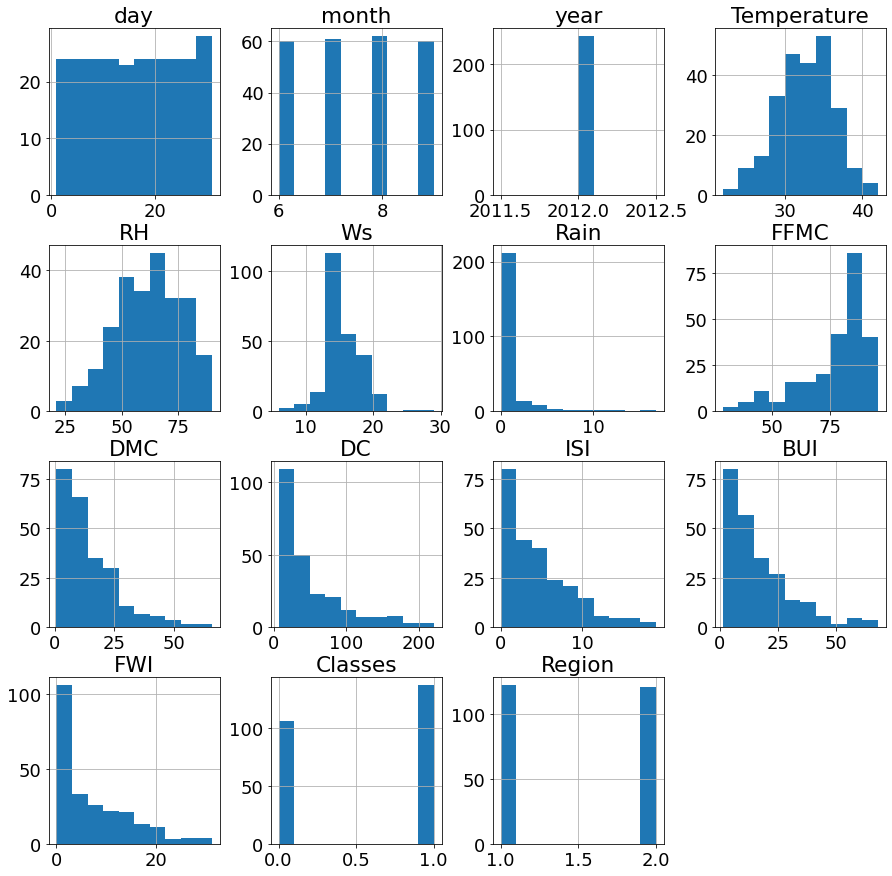

```python
df.hist(figsize = (15,15))
plt.show()
#checking the overall distribution of everything - mel
```

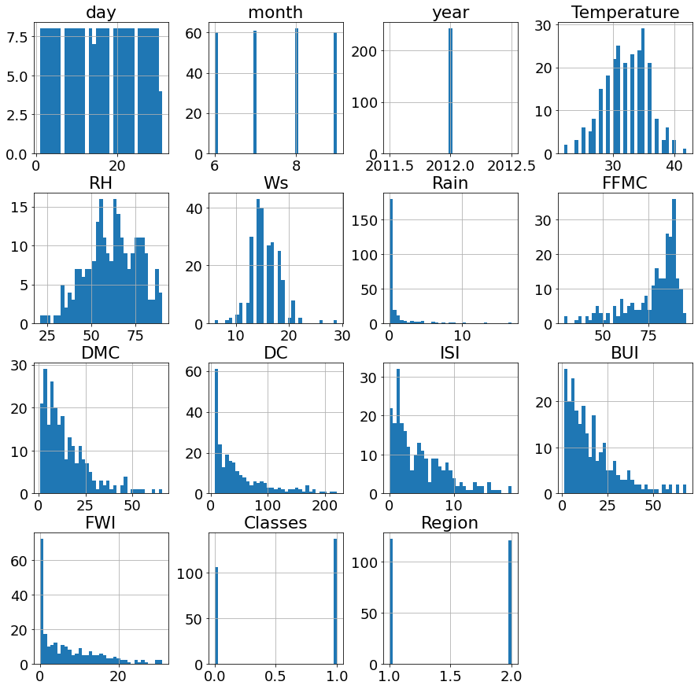

```python
#same as above but with better binning

df.hist(figsize = (15,15), bins= 35)
plt.show()
#Mel
```

```python
df.describe()
```

|  | day | month | year | Temperature | RH | Ws | Rain | FFMC | DMC | DC | ISI | BUI | FWI | Classes | Region |
| --- | --- | --- | --- | --- | --- | --- | --- | --- | --- | --- | --- | --- | --- | --- | --- |
| count | 243.000000 | 243.000000 | 243.0 | 243.000000 | 243.000000 | 243.000000 | 243.000000 | 243.000000 | 243.000000 | 243.000000 | 243.000000 | 243.000000 | 243.000000 | 243.000000 | 243.000000 |
| mean | 15.761317 | 7.502058 | 2012.0 | 32.152263 | 62.041152 | 15.493827 | 0.762963 | 77.842387 | 14.680658 | 49.430864 | 4.742387 | 16.690535 | 7.035391 | 0.563786 | 1.497942 |
| std | 8.842552 | 1.114793 | 0.0 | 3.628039 | 14.828160 | 2.811385 | 2.003207 | 14.349641 | 12.393040 | 47.665606 | 4.154234 | 14.228421 | 7.440568 | 0.496938 | 0.501028 |
| min | 1.000000 | 6.000000 | 2012.0 | 22.000000 | 21.000000 | 6.000000 | 0.000000 | 28.600000 | 0.700000 | 6.900000 | 0.000000 | 1.100000 | 0.000000 | 0.000000 | 1.000000 |
| 25% | 8.000000 | 7.000000 | 2012.0 | 30.000000 | 52.500000 | 14.000000 | 0.000000 | 71.850000 | 5.800000 | 12.350000 | 1.400000 | 6.000000 | 0.700000 | 0.000000 | 1.000000 |
| 50% | 16.000000 | 8.000000 | 2012.0 | 32.000000 | 63.000000 | 15.000000 | 0.000000 | 83.300000 | 11.300000 | 33.100000 | 3.500000 | 12.400000 | 4.200000 | 1.000000 | 1.000000 |
| 75% | 23.000000 | 8.000000 | 2012.0 | 35.000000 | 73.500000 | 17.000000 | 0.500000 | 88.300000 | 20.800000 | 69.100000 | 7.250000 | 22.650000 | 11.450000 | 1.000000 | 2.000000 |
| max | 31.000000 | 9.000000 | 2012.0 | 42.000000 | 90.000000 | 29.000000 | 16.800000 | 96.000000 | 65.900000 | 220.400000 | 19.000000 | 68.000000 | 31.100000 | 1.000000 | 2.000000 |

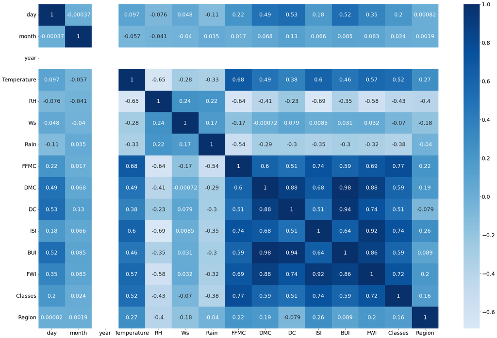

```python
## heat map of everything!
#mel

plt.figure(figsize = (30,20))
sns.heatmap(data = df.corr(), cmap = "Blues", annot = True, center = 0)
```

```python
#Creating a much simpler way to plot these pie charts!
#Mel
fire_counts_df = df.Classes.value_counts()

fire_counts_test = test.Classes.value_counts()

fire_counts_train = train.Classes.value_counts()
```

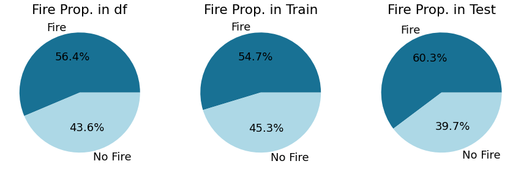

```python
##Created a plot with three subplots and then added the df value counts created above
##Added the labels, the autopct with the format, and then the title and colors.
## I tried to make the colors similar to the heat map above
#Mel
labels = ["Fire", "No Fire"]
fig = plt.figure(figsize = (15,15))
ax1 = plt.subplot2grid((1,3),(0,0))
plt.pie(fire_counts_df, labels = labels, autopct= '%.1f%%', colors = ("#187194", "lightblue"))
plt.title("Fire Prop. in df")
ax2 = plt.subplot2grid((1,3),(0,1))
plt.pie(fire_counts_train, labels = labels, autopct= '%.1f%%', colors = ("#187194", "lightblue"))
plt.title("Fire Prop. in Train")
ax3 = plt.subplot2grid((1,3),(0,2))
plt.pie(fire_counts_test, labels = labels, autopct= '%.1f%%', colors = ("#187194", "lightblue"))
plt.title("Fire Prop. in Test")
plt.show()
```

## 3 Developing the model

*by Arush*

```python
# Arush

# Confusion Matrix Helper

def confusion_matrix_data(data, actual_values, model, cutoff = 0.5):

    # predict the values
    pred_values = model.predict(data) # these will be probabilities

    pred_values = pred_values.apply(lambda x: 0 if x < 0 else x)
    pred_values = pred_values.apply(lambda x: 1 if x > 1 else x)

    # Specify bins to do the cutoff thing
    bins = np.array([0, cutoff, 1])

    # Confusion matrix
    cm = np.histogram2d(actual_values, pred_values, bins = bins)[0]

    cm_df = pd.DataFrame(cm)
    cm_df.columns = ['Predicted 0','Predicted 1']
    cm_df = cm_df.rename(index={0: 'Actual 0',1:'Actual 1'})

    accuracy = (cm[0,0]+cm[1,1])/cm.sum()

    fnr = (cm[1,0])/(cm[1,0]+cm[1,1])
    fpr = (cm[0,1])/(cm[0,0]+cm[0,1])

    precision = (cm[1,1])/(cm[1,1]+cm[0,1])
    tpr = (cm[1,1])/(cm[1,0]+cm[1,1]) # Recall

    # fpr_roc, tpr_roc, auc_thresholds = roc_curve(actual_values, pred_values)
    # auc_value = (auc(fpr_roc, tpr_roc))# AUC of ROC
    sns.heatmap(cm_df, annot=True, cmap='Blues', fmt='g')
    plt.ylabel("Actual Values")
    plt.xlabel("Predicted Values")
    print("Classification accuracy = {:.1%}".format(accuracy))
    print("Precision = {:.1%}".format(precision))
    print("TPR or Recall = {:.1%}".format(tpr))
    print("FNR = {:.1%}".format(fnr))
    print("FPR = {:.1%}".format(fpr))
    # print("ROC-AUC = {:.1%}".format(auc_value))
```

### 3.1 Figure 1

```python
# Arush

# Base model

logit_model = smf.logit(formula = 'Classes~Temperature+RH+Ws+Rain+FFMC', data = train).fit(method = 'bfgs')
```

```
Classification accuracy = 97.1%
Precision = 94.9%
TPR or Recall = 100.0%
FNR = 0.0%
FPR = 6.5%
```

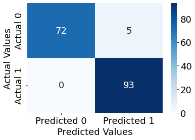

```python
confusion_matrix_data(train, train.Classes, logit_model, 0.3)
```

```
Classification accuracy = 97.3%
Precision = 97.7%
TPR or Recall = 97.7%
FNR = 2.3%
FPR = 3.4%
```

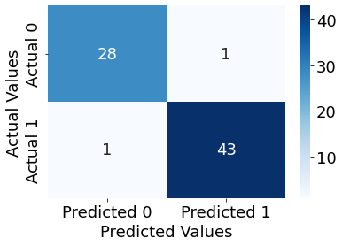

```python
# This confusion matrix is very different from what we initially received. That can be found in
# project_main_notebook. We are not sure why it looks different

confusion_matrix_data(test, test.Classes, logit_model, 0.3)
```

```python
# Arush

# Stepwise Selection Helper

# Forward Stepwise Selection

# Defining helpers

X = train[['Temperature','Rain','Ws','RH','FFMC','DMC','DC','ISI','BUI','FWI']]

def processSubset(predictor_subset):
    model = smf.ols('Classes~' + '+'.join(predictor_subset),data = train).fit()
    Rsquared = model.rsquared
    return {"model":model, "Rsquared":Rsquared}

def forward(predictors):

    remaining_predictors = [p for p in X.columns if p not in predictors]

    tic = time.time()

    results = []

    for p in remaining_predictors:
        results.append(processSubset(predictors+[p]))

    models = pd.DataFrame(results)

    best_model = models.loc[models['Rsquared'].argmax()]

    toc = time.time()
    print("Processed ", models.shape[0], "models on", len(predictors)+1, "predictors in", (toc-tic), "seconds.")

    return best_model


def forward_selection():
    models_best = pd.DataFrame(columns=["Rsquared", "model"])

    tic = time.time()
    predictors = []

    for i in range(1,len(X.columns)+1):
        models_best.loc[i] = forward(predictors)
        predictors = list(models_best.loc[i]["model"].params.index[1:])

    toc = time.time()
    print("Total elapsed time:", (toc-tic), "seconds.")
    return models_best


def best_sub_plots():
    plt.figure(figsize=(20,10))
    plt.rcParams.update({'font.size': 18, 'lines.markersize': 10})

    plt.subplot(2, 2, 1)

    plt.plot(models_best["Rsquared"])
    plt.xlabel('# Predictors')
    plt.ylabel('Rsquared')


    rsquared_adj = models_best.apply(lambda row: row[1].rsquared_adj, axis=1)

    plt.subplot(2, 2, 2)
    plt.plot(rsquared_adj)
    plt.plot(1+rsquared_adj.argmax(), rsquared_adj.max(), "or")
    plt.xlabel('# Predictors')
    plt.ylabel('adjusted rsquared')

    aic = models_best.apply(lambda row: row[1].aic, axis=1)

    plt.subplot(2, 2, 3)
    plt.plot(aic)
    plt.plot(1+aic.argmin(), aic.min(), "or")
    plt.xlabel('# Predictors')
    plt.ylabel('AIC')

    bic = models_best.apply(lambda row: row[1].bic, axis=1)

    plt.subplot(2, 2, 4)
    plt.plot(bic)
    plt.plot(1+bic.argmin(), bic.min(), "or")
    plt.xlabel('# Predictors')
    plt.ylabel('BIC')
```

```python
# Arush

# Subset selected through straight up stepwise selection
# Finding best subset of degree two interactions

X = train[['FFMC', 'FWI', 'RH', 'BUI', 'Ws', 'Rain']]

X_backup = train[['FFMC', 'FWI', 'RH', 'BUI', 'Ws', 'Rain']]

for combo in itertools.combinations(X_backup.columns, 2):
    train['_'.join(combo)] = train[combo[0]]*train[combo[1]] # creating int. terms
    test['_'.join(combo)] = test[combo[0]]*test[combo[1]] # creating int, terms
    X.loc[:,'_'.join(combo)] = train.loc[:,'_'.join(combo)] # creating the same x
```

```python
models_best = forward_selection()
```

```
Processed  21 models on 1 predictors in 0.05980801582336426 seconds.
Processed  20 models on 2 predictors in 0.059632062911987305 seconds.
Processed  19 models on 3 predictors in 0.06123995780944824 seconds.
Processed  18 models on 4 predictors in 0.07277274131774902 seconds.
Processed  17 models on 5 predictors in 0.08155989646911621 seconds.
Processed  16 models on 6 predictors in 0.08335995674133301 seconds.
Processed  15 models on 7 predictors in 0.08640599250793457 seconds.
Processed  14 models on 8 predictors in 0.09087514877319336 seconds.
Processed  13 models on 9 predictors in 0.08913683891296387 seconds.
Processed  12 models on 10 predictors in 0.09248685836791992 seconds.
Processed  11 models on 11 predictors in 0.08733510971069336 seconds.
Processed  10 models on 12 predictors in 0.08751702308654785 seconds.
Processed  9 models on 13 predictors in 0.08062005043029785 seconds.
Processed  8 models on 14 predictors in 0.07751107215881348 seconds.
Processed  7 models on 15 predictors in 0.07890200614929199 seconds.
Processed  6 models on 16 predictors in 0.06794595718383789 seconds.
Processed  5 models on 17 predictors in 0.05921792984008789 seconds.
Processed  4 models on 18 predictors in 0.05070900917053223 seconds.
Processed  3 models on 19 predictors in 0.03722691535949707 seconds.
Processed  2 models on 20 predictors in 0.02723407745361328 seconds.
Processed  1 models on 21 predictors in 0.01456308364868164 seconds.
Total elapsed time: 1.4749460220336914 seconds.
```

### 3.2 Figure 2

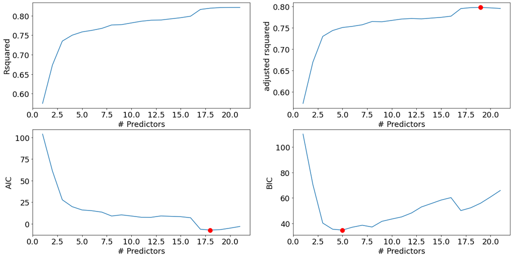

```python
best_sub_plots()

# Note: The subplots here look different than the subplots in our main code notebook (Project_Main_Notebook)
# We have no idea why this is the case. However, any model with 13-18 predictors gives us a recall of 100%
# so it shouldn't matter whether or not we use 13 or 18 predictors
```

```python
best_fwd_reg_model_AIC_some = models_best['model'][13]
best_fwd_reg_model_AIC_some.summary()
```

OLS Regression Results

| Dep. Variable: | Classes | R-squared: | 0.789 |
| --- | --- | --- | --- |
| Model: | OLS | Adj. R-squared: | 0.771 |
| Method: | Least Squares | F-statistic: | 44.80 |
| Date: | Mon, 13 Mar 2023 | Prob (F-statistic): | 6.68e-46 |
| Time: | 13:42:08 | Log-Likelihood: | 9.5103 |
| No. Observations: | 170 | AIC: | 8.979 |
| Df Residuals: | 156 | BIC: | 52.88 |
| Df Model: | 13 |  |  |
| Covariance Type: | nonrobust |  |  |

|  | coef | std err | t | P>\|t\| | [0.025 | 0.975] |
| --- | --- | --- | --- | --- | --- | --- |
| Intercept | -1.1565 | 0.628 | -1.842 | 0.067 | -2.397 | 0.084 |
| FFMC | 0.0249 | 0.009 | 2.620 | 0.010 | 0.006 | 0.044 |
| FWI_RH | 0.0014 | 0.000 | 6.434 | 0.000 | 0.001 | 0.002 |
| BUI_Ws | 0.0009 | 0.001 | 1.181 | 0.239 | -0.001 | 0.002 |
| FWI_Rain | 0.0806 | 0.022 | 3.632 | 0.000 | 0.037 | 0.124 |
| FWI_BUI | -0.0007 | 0.000 | -2.611 | 0.010 | -0.001 | -0.000 |
| BUI_Rain | 0.0071 | 0.008 | 0.835 | 0.405 | -0.010 | 0.024 |
| RH_Rain | 0.0015 | 0.001 | 2.897 | 0.004 | 0.000 | 0.003 |
| FFMC_Rain | -0.0031 | 0.001 | -2.973 | 0.003 | -0.005 | -0.001 |
| FFMC_Ws | -0.0011 | 0.001 | -1.656 | 0.100 | -0.002 | 0.000 |
| BUI | -0.1213 | 0.051 | -2.357 | 0.020 | -0.223 | -0.020 |
| FFMC_BUI | 0.0012 | 0.001 | 1.886 | 0.061 | -5.43e-05 | 0.002 |
| Ws | 0.0459 | 0.044 | 1.035 | 0.302 | -0.042 | 0.133 |
| RH_Ws | 9.154e-05 | 0.000 | 0.623 | 0.534 | -0.000 | 0.000 |

| Omnibus: | 2.877 | Durbin-Watson: | 1.977 |
| --- | --- | --- | --- |
| Prob(Omnibus): | 0.237 | Jarque-Bera (JB): | 2.418 |
| Skew: | 0.245 | Prob(JB): | 0.298 |
| Kurtosis: | 3.318 | Cond. No. | 8.32e+04 |

Notes:  
[1] Standard Errors assume that the covariance matrix of the errors is correctly specified.  
[2] The condition number is large, 8.32e+04. This might indicate that there are  
strong multicollinearity or other numerical problems.

```
Classification accuracy = 91.2%
Precision = 86.1%
TPR or Recall = 100.0%
FNR = 0.0%
FPR = 19.5%
```

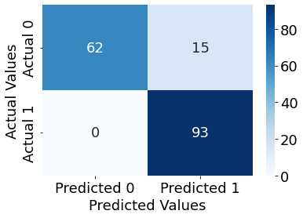

```python
confusion_matrix_data(train, train.Classes, best_fwd_reg_model_AIC_some, 0.3)
```

### 3.3 Figure 3

```
Classification accuracy = 93.2%
Precision = 89.8%
TPR or Recall = 100.0%
FNR = 0.0%
FPR = 17.2%
```

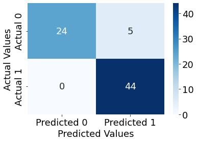

```python
confusion_matrix_data(test, test.Classes, best_fwd_reg_model_AIC_some, 0.3)
```

### 3.4 Code fitting the final model

```python
final_model = smf.logit(formula = 'Classes~FFMC + FWI*RH + BUI*Ws + FWI*Rain + RH + FFMC*RH + FFMC*FWI + FWI + FFMC*Ws + BUI + RH*Ws + FFMC*BUI + RH*BUI', data = train).fit(method = 'bfgs')
```